# Lecture 4

# Recombination

Last week we considered how, as populations evolve, divergence builds up at individual sequences.

So far, the evolutionary processes we have talked about have been summable up in simple ways, in particular because we have assumed each locus’ trajectory is independent of others.

Today, we’ll start to consider when we can make that assumption, and when we cannot, and how recombination shapes evolution writ large.

## Sexual reproduction is rare

Only a small sliver of the total tree of life has to sexually reproduce.

Prokaryotes and Archae do not sexually reproduce, many fungi and protists only do so when needed.

So, it makes sense to first consider a world with no sexual reproduction.

## Asexual reproduction

Our earlier schematic of a WF life-cycle had a diploid adult producing infinite gametes.

Now consider a haploid generation, which produces the next haploid generation by random sampling - some individuals bud, others die out.

Each individual lineage is well approximated by a branching process - a mathematical structure describing budding dynamics of a population.

## Some true facts about branching processes

Unless a lineage on average produces more than 1 offspring per generation, it is guaranteed to go extinct at some point.

What is the expected number of offspring in a WF formulation?

For each offspring, the chance they descend from you is $\frac{1}{N}$. There are $N$ offspring.

So: each individual lineage is guaranteed to go extinct in the long run.

Caveat: this does not mean the species is guaranteed to go extinct - in fact, we’ve made sure it doesn’t since population size is held constant at $N$.

## Consequences for genetic diversity

Any time a mutation arises, it starts a new lineage.

This lineage can become fixed with probability $1/N$.

All other mutations carried by that lineage become fixed as well, since they are tied to it.

Similarly - all other mutations not present in that lineage become lost as it becomes fixed.

## What is the genetic diversity of an asexual population?

In a neutral population, dynamics remain surprisingly similar, as any sweeps take long (same logic as Neutral Theory: $\frac{1}{N}$ is the rate of fixation)

If there are selective sweeps (some lineages better than others) - populations almost fully clonal except during sweep (Desai, Walczak, and Fisher 2013).

This is called *clonal interference*: clones are competing with each other, but only one (and its subset mutations) can win.

Because selection is probably happening all of the time, you may expect asexual lineages to show very low/no genetic diversity.

## Genetic diversity in asexual lineages

By definition, bacterial species are labeled as “different” if $d>0.05$. That means $\pi$ in any population rarely goes above 0.05 as well.

But also - $d$ is calculated for *shared* genes, often called core genes.

Many genes in bacteria are *accessory*, they can have a copy or not.

In this sense - lots of genetic diversity within species, but not in the subset of genes that are core.

## Why are there so many accessory genes?

Sexual reproduction is rare, but its main effect: recombination, is not.

Viral lineages recombine in three distinct ways (Simon-Loriere and Holmes 2011)

[figure not shown]

## Asexual recombination cntd

Bacterial lineages recombine via transformation, transduction and conjugation.

The frequency of recombination in prokaryotic lineages is debated, but likely quite universal (Conrad et al. 2024)

[figure not shown]

## So: recombination probably universal, but what does it do?

When population geneticists talk about recombination, it is mostly, but not always, referring to meiotic recombination.

More generally, we refer to it as the process that breaks down linkage.

*Linkage* is how correlated the inheritance of two loci is.

Imagine our asexual population, no recombination. An individual with mutations `AB` will always have offspring who carry `AB`, excluding mutation.

Now, imagine a sexual individual with genotype `AB` - how frequently will their offspring be `AB`?

Because they are sexually reproducing, they first need to form a diploid, so depends on allele frequencies!

## Linkage equilibrium and linkage disequilibrium

These are horrible terms, because they are false.

Linkage equilibrium refers to the expected frequency of co-inheriting two alleles when they are unlinked.

Recall your high-school Punnet squares: if `A` in $p_A$ frequency, and `B` in $p_B$, then $p_{AB}$ = ??

Linkage Disequilibrium (LD) is a measure of how far off this expectation the inheritance of two alleles is:

$$D_{ij} = p_{ij}-p_ip_j$$

## D in practice

The frequency of the four possible genotypes will be:

$$\begin{cases}
p_{AB} = p_Ap_B+D \\
p_{Ab} = p_Aq_B-D \\
p_{aB} = q_Ap_B-D \\
p_{ab} = q_aq_B+D
\end{cases}$$

Because these values depend on allele frequencies, they don’t scale nicely linearly.

## When is $D$ maximized?

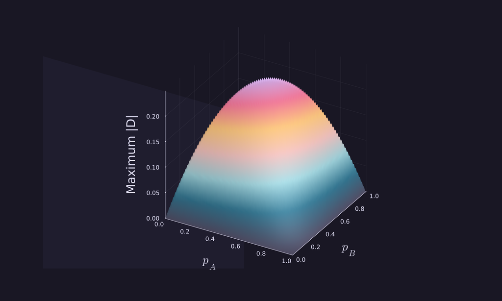

## Alternatives to $D$

There are more intuitive ways of measuring LD as a result, but we’ll come back to $D$ time and again.

One is to scale it by its maximum possible value for any allele frequency:

$$\begin{cases}
D_{ij}' = \frac{D_{ij}}{max(-p_iq_j,-p_jq_i)}, for D<0 \\
D_{ij}' = \frac{D_{ij}}{min(p_iq_j,q_ip_j)}, for D>0 \\
\end{cases}$$

Now it ranges neatly between -1 and +1.

## LD as a correlation

Alternatively, we can think of LD as the correlation of genotypes in individuals for any pair of loci:

$$r_{ij}^2 = \frac{D_{ij}^2}{p_ip_jq_iq_j}$$

So, let’s say you have this genotype matrix:

| A | B |
| --- | --- |
| 1 | 1 |
| 1 | 1 |
| 0 | 0 |
| 0 | 0 |

Knowing what allele is at A perfectly predicts what allele is at B.

## What does recombination do?

Recombination, whether meiotic or otherwise, breaks up these correlations.

The effect of recombination is to reduce LD between pairs of alleles:

$$D_{ij}^` =\left(1-r_{ij}\right)D_{ij}$$

Where $r_{ij}$ is the rate of recombination between loci $i$ and $j$.

## How quick is the decay?

```
[ Info: Saved animation to /tmp/jl_SrKRMxshoX.gif
```

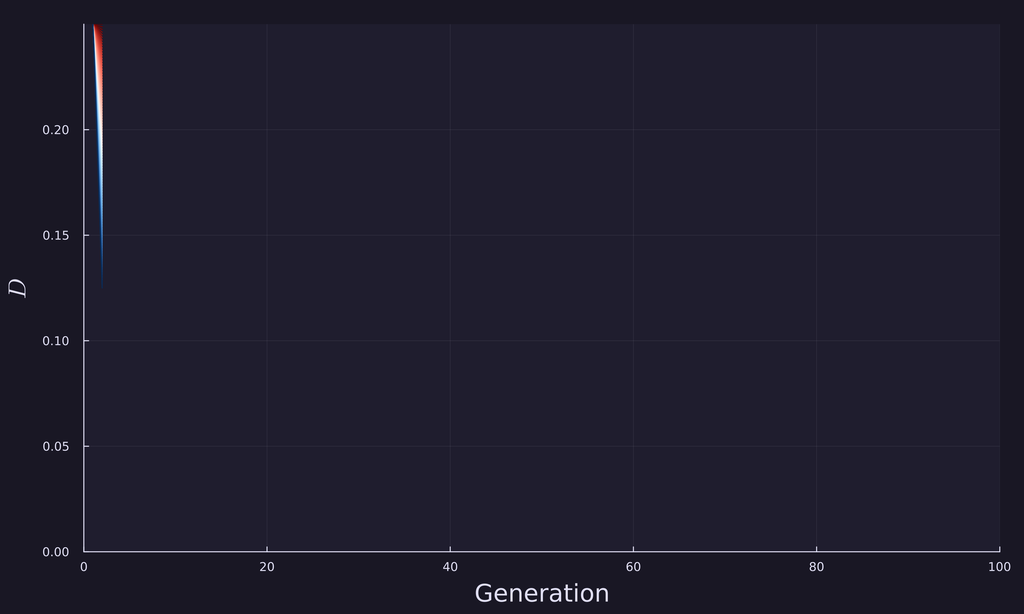

## Key take-aways

When loci are unlinked ($r=0.5$), LD rapidly decays to 0.

Unlike HW - single generation not enough to go to 0!

Even when loci are closely linked ($r \ll 0.5$ ), decay is fairly quick.

What keeps loci in LD then?

## Forces that generate LD

Anything that creates *joint* identity-by-descent (some examples given).

Population structure/migration (Price et al. 2008).

Mating preference (Kirkpatrick 1982).

Direct selection (but only weakly) (Liu et al. 2014).

Epistatic selection (selection on combination of alleles) (Nagylaki 1993).

## LD and population size

In the long run, how much LD there is between sites also depends on population size.

Small populations - fewer recombination events. Expectations we showed before are true for infinite populations.

Population effect captured in $\rho$ - the population recombination rate.

$$\rho = 4 N_E r$$

## $\rho$ in the long run

In the long run, there are some fairly intuitive expectations for how correlated any pair of alleles will be given $\rho$.

Think of loci $i$ and $j$ - they are some $r$ distance apart. How well can you predict their eventual correlation?

If you think of the probability that they are both passed on together (joint identity-by-descent), that will become the long term correlation at the pair of loci. (Sved 1971)

## Long term LD cntd

More formally, let $Q_n$ be the probability that two alleles at different loci are jointly identical by descent after $n$ generations

$$Q_n = \frac{1}{2N}(1-r)^2+\left(1-\frac{1}{2N}\right)Q_{n-1}(1-r)^2$$

That is - either they are identical by descent just now, or they were the previous generation.

Some wailing and gnashing of teeth later, if we assume $r \ll 0.5$, we can get:

$$E[Q_\infty] = \frac{1}{1+4Nr} = \frac{1}{1+\rho}$$

## So:

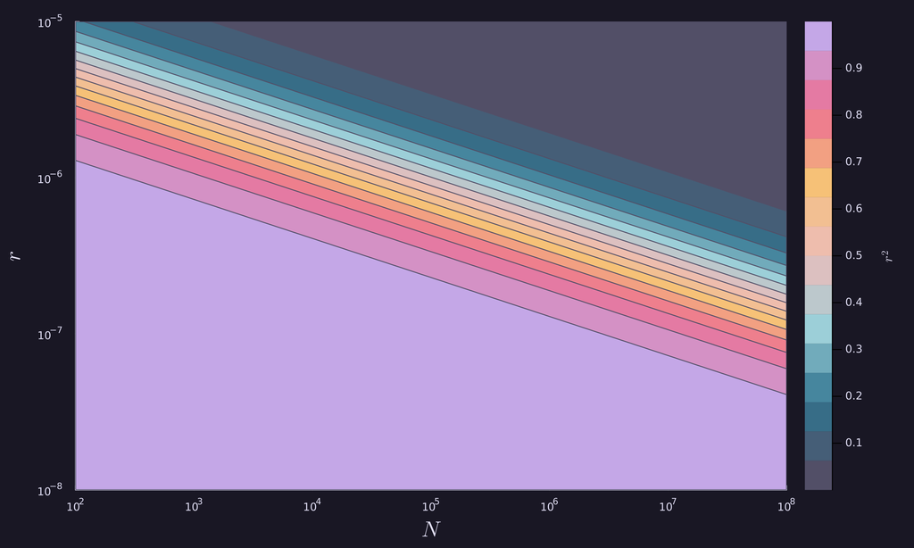

## Things you will read/think that are subtly wrong:

- These loci are only in LD because of proximity
  - What’s the population size? How did that LD build up to begin with?
- Long-range LD is great evidence for selection
  - Or population structure, or structural variation.
- There’s no LD expected between these loci since they are on different chromosomes.
  - LD can build up *within* a generations. Selection/assortative mating can maintain it between chromosomes.

## LD and pop gen analyses

It’s easier to think about $r^2$ as a measure of LD here.

If two loci are in perfect LD ($r^2 = 1$), then knowing one gives you *all* of the information about the second.

In practice, this means that the loci are replicates of the same information.

This will lead to bad statistical inference, and you’ll have to deal with more samples than you strictly need.

LD-pruning refers to the practice of keeping only the first or most common allele when multiple alleles are in high LD.

Reduces the amount of data to keep track of, accounts (in some sense) for non-independence of different data points.

## LD -pruning vs LD -clumping

The problem with pruning is the most common/first allele may not be the interesting one.

Most pipelines don’t have a step to go back and check what was in LD with the identified locus, so may miss important factors.

LD-clumping tries to avoid this by picking the most important SNPs in any region. First designate interesting/important loci, then remove other that are in LD with those.

Often good practice to run this on your data initially, and if possible, repeat data without pruning/clumping and see if results are robust.

## Other ways of dealing with LD: LD-decay

As you saw, LD decays fairly quickly with increasing recombination distance.

Windows spaced apart by distance where $r^2$ is negligible.

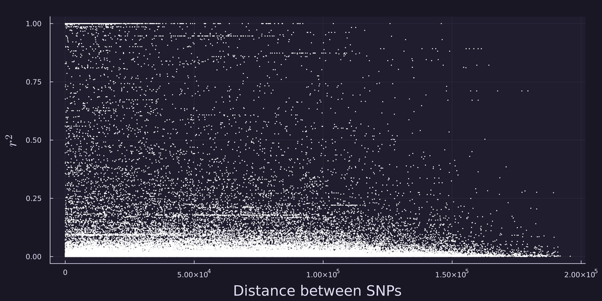

## Another way of thinking of LD

We can also think of LD as occurring on different regions within a genome:

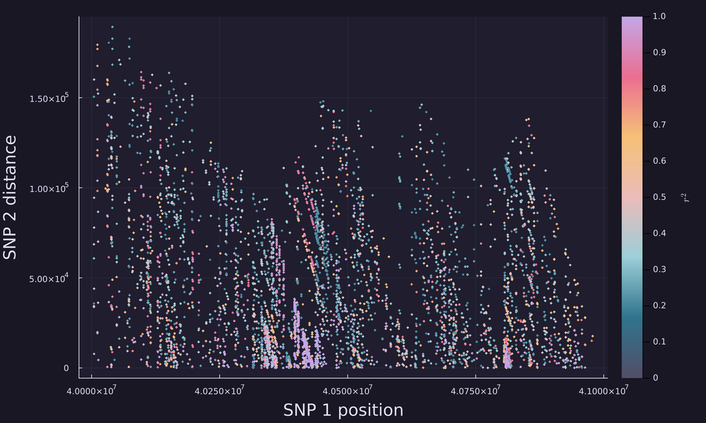

## What can this tell you?

Evolved SVs (here an inversion in Europeans (a) not found in Africans (b)). (Stefansson et al. 2005)

[figure not shown]

## Worth knowing: $D_{ijk}$ and above

You can also calculate the LD between triplets/quadruplets… of alleles.

The number of such comparisons grows very rapidly, but they can often be useful when thinking about a set of loci that are, as a group, more correlated than expected.

$$D_{\Bbb{A}} = P_{\Bbb{A}}-\sum_{a \in \Bbb{A}}D_aP_a$$

So - every higher degree $D$ has to account for all of the LD in all possible subsets. Any positive/negative values are therefore deviations *beyond* what’s happening due to LD between pairs.

## iHS, EHH, ROH

There are multiple statistics that work off of the fact that recombination breaks apart certain patterns in the genome, thus, we can look for “runs” of patterns as evidence of *recent* evolutionary events, or selection acting along the whole region.

- ROH - Runs of Homozygosity. We mentioned these previously. They can be indicators of inbreeding, since:
  - Homozygosity is caused by more Identity-by-descent than expected from HW/WF
  - The length of such regions can tell you how far from the inbreeding event this chunk descended from (since only recombination will break up the ROH). ## cntd.
- iHS, - integradted Homozygosity Score, EHH - Extended Haplotype: searching for selection. (Klassmann and Gautier 2022)
  - Selection at a locus will force nearby regions to hitchhike. This generates long range LD, and, if selection is strong, long range homozygosity.

[figure not shown]

## Getting rid of LD - practically

A common occurence in evolutionary studies is two populations that are different by some interesting trait.

You might try to first look at divergence across the genome to detect *what* is causing this interesting trait to appear.

If divergence has ocurred genome-wide - might be very hard to do.

If populations can still interbreed: QTL analysis

## Quantitative Trait Loci

So far we have been agnostic about *what* our genes do, because we haven’t needed to worry about it.

Let’s consider an allele that impacts some measurable trait, say height.

How can we detect this allele?

## Approach 1: Genome-wide association study

If variance within your population is high enough, you can get away with GWAS.

We’ll talk more about how GWAS is performed later in the semester, but at it’s core: fit a linear model of $trait ~ genotype$ at each locus.

More likely for some traits - the whole population has the trait of interest, and no real variation.

In other words - the trait is *correlated* to the population’s ancestry as a whole - there’s LD here.

## Approach 2: Break apart LD

If you cross this population with a closely related one, which does not have the trait, you can run a QTL analysis.

Each generation past F1, the LD between Pop 1 ancestry and the causal allele decreases by $r$ between that allele and everywhere else in the genome.

Easy to narrow to causal chromosome (if single locus) within two generations. Why?

## Approach 3: Let nature do it

To narrow down the trait inheritance, it’s often useful/necessary to go many generations deeper.

One natural alternative - areas with active hybridization.

If your populations are, by chance, still hybridizing, there has been a natural QTL experiment happening at the tension zone.

## Next week: population structure and migration

Considering how alleles are exchanged between populations will be the focus next week.

We will also introduce the coalescent more formally, so be prepared for a fairly math heavy time.

Oc 7-9th: Initial project meetings. Keep an eye out for a sign up sheet on the slack, start thinking about a data set you’d like to analyze more thoroughly.

## References

Conrad, Roth E., Catherine E. Brink, Tomeu Viver, Luis M. Rodriguez-R, Borja Aldeguer-Riquelme, Janet K. Hatt, Stephanus N. Venter, Ramon Rossello-Mora, Rudolf Amann, and Konstantinos T. Konstantinidis. 2024. “Microbial Species and Intraspecies Units Exist and Are Maintained by Ecological Cohesiveness Coupled to High Homologous Recombination.” *Nature Communications* 15 (1). https://doi.org/10.1038/s41467-024-53787-0.

Desai, Michael M, Aleksandra M Walczak, and Daniel S Fisher. 2013. “Genetic Diversity and the Structure of Genealogies in Rapidly Adapting Populations.” *Genetics* 193 (2): 565–85. https://doi.org/10.1534/genetics.112.147157.

Kirkpatrick, Mark. 1982. “SEXUAL SELECTION AND THE EVOLUTION OF FEMALE CHOICE.” *Evolution* 36 (1): 1–12. https://doi.org/10.1111/j.1558-5646.1982.tb05003.x.

Klassmann, Alexander, and Mathieu Gautier. 2022. “Detecting Selection Using Extended Haplotype Homozygosity (EHH)-Based Statistics in Unphased or Unpolarized Data.” Edited by Muhammad Abdul Rehman Rashid. *PLOS ONE* 17 (1): e0262024. https://doi.org/10.1371/journal.pone.0262024.

Liu, Huiming, Anders C Sørensen, Theo HE Meuwissen, and Peer Berg. 2014. “Allele Frequency Changes Due to Hitch-Hiking in Genomic Selection Programs.” *Genetics Selection Evolution* 46 (1): 8. https://doi.org/10.1186/1297-9686-46-8.

Nagylaki, T. 1993. “The Evolution of Multilocus Systems Under Weak Selection.” *Genetics* 134 (2): 627–47. https://doi.org/10.1093/genetics/134.2.627.

Price, Alkes L., Michael E. Weale, Nick Patterson, Simon R. Myers, Anna C. Need, Kevin V. Shianna, Dongliang Ge, et al. 2008. “Long-Range LD Can Confound Genome Scans in Admixed Populations.” *The American Journal of Human Genetics* 83 (1): 132–35. https://doi.org/10.1016/j.ajhg.2008.06.005.

Simon-Loriere, Etienne, and Edward C. Holmes. 2011. “Why Do RNA Viruses Recombine?” *Nature Reviews Microbiology* 9 (8): 617–26. https://doi.org/10.1038/nrmicro2614.

Stefansson, Hreinn, Agnar Helgason, Gudmar Thorleifsson, Valgerdur Steinthorsdottir, Gisli Masson, John Barnard, Adam Baker, et al. 2005. “A Common Inversion Under Selection in Europeans.” *Nature Genetics* 37 (2): 129–37. https://doi.org/10.1038/ng1508.

Sved, J. A. 1971. “Linkage Disequilibrium and Homozygosity of Chromosome Segments in Finite Populations.” *Theoretical Population Biology* 2 (2): 125–41. https://doi.org/10.1016/0040-5809(71)90011-6.